#Formulation of clusters using K-Means with k = 2 (WSS)

```r
wss_kmeans <- kmeans(scaled_data,centers = 2,nstart=50)
wss_kmeans
```

```
## K-means clustering with 2 clusters of sizes 11, 10
##
## Cluster means:
##   Market_Cap       Beta   PE_Ratio        ROE        ROA Asset_Turnover
## 1  0.6733825 -0.3586419 -0.2763512  0.6565978  0.8344159      0.4612656
## 2 -0.7407208  0.3945061  0.3039863 -0.7222576 -0.9178575     -0.5073922
##     Leverage Rev_Growth Net_Profit_Margin
## 1 -0.3331068 -0.2902163         0.6823310
## 2  0.3664175  0.3192379        -0.7505641
##
## Clustering vector:
##  [1] 1 2 2 1 2 2 1 2 2 1 1 2 1 2 1 1 1 2 1 2 1
##
## Within cluster sum of squares by cluster:
## [1] 43.30886 75.26049
##  (between_SS / total_SS =  34.1 %)
##
## Available components:
##
## [1] "cluster"      "centers"      "totss"        "withinss"     "tot.withinss"
## [6] "betweenss"    "size"         "iter"         "ifault"
```

#Formulation of clusters using K-Means with k = 5 (Silhouette)

```r
silhouette_kmeans <- kmeans(scaled_data,centers=5,nstart=50)
silhouette_kmeans
```

```
## K-means clustering with 5 clusters of sizes 2, 3, 4, 4, 8
##
## Cluster means:
##    Market_Cap       Beta    PE_Ratio        ROE        ROA Asset_Turnover
## 1 -0.43925134 -0.4701800  2.70002464 -0.8349525 -0.9234951      0.2306328
## 2 -0.87051511  1.3409869 -0.05284434 -0.6184015 -1.1928478     -0.4612656
## 3 -0.76022489  0.2796041 -0.47742380 -0.7438022 -0.8107428     -1.2684804
## 4  1.69558112 -0.1780563 -0.19845823  1.2349879  1.3503431      1.1531640
## 5 -0.03142211 -0.4360989 -0.31724852  0.1950459  0.4083915      0.1729746
##      Leverage Rev_Growth Net_Profit_Margin
## 1 -0.14170336 -0.1168459      -1.416514761
## 2  1.36644699 -0.6912914      -1.320000179
## 3  0.06308085  1.5180158      -0.006893899
## 4 -0.46807818  0.4671788       0.591242521
## 5 -0.27449312 -0.7041516       0.556954446
##
## Clustering vector:
##  [1] 5 1 5 5 3 2 5 2 3 5 4 2 4 3 4 5 4 1 5 3 5
##
## Within cluster sum of squares by cluster:
## [1]  2.803505 15.595925 12.791257  9.284424 21.879320
##  (between_SS / total_SS =  65.4 %)
##
## Available components:
##
## [1] "cluster"      "centers"      "totss"        "withinss"     "tot.withinss"
## [6] "betweenss"    "size"         "iter"         "ifault"
```

#Cluster Plot (WSS)

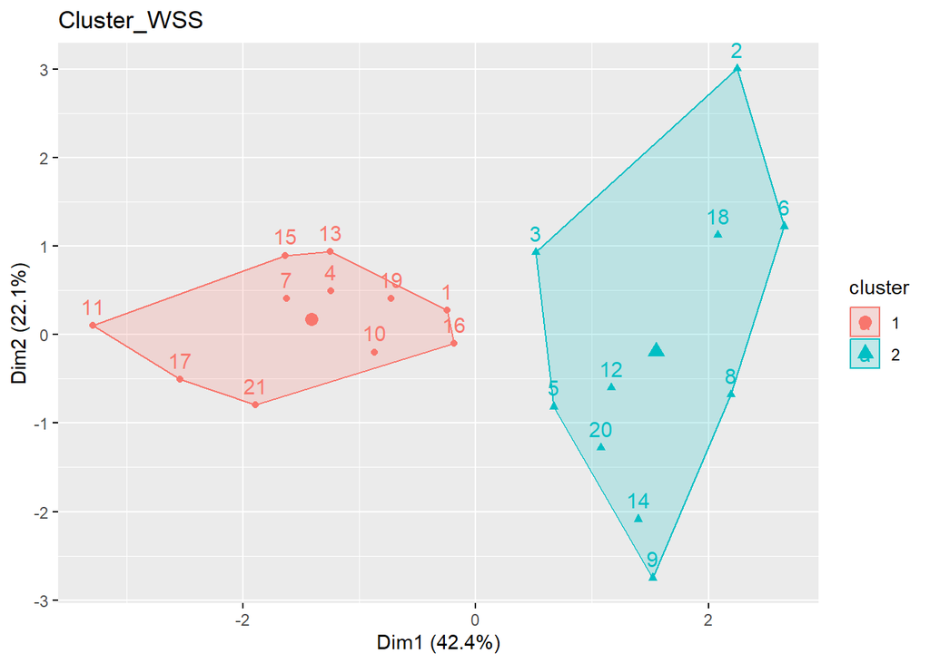

```r
fviz_cluster(wss_kmeans,scaled_data[,-c(1:2,12:15)],main="Cluster_WSS")
```

#Cluster Plot (Silhouette)

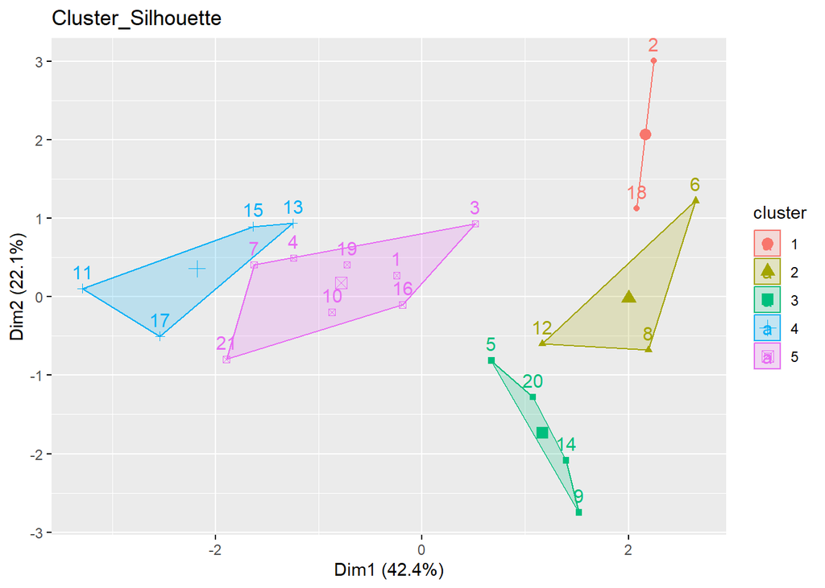

```r
fviz_cluster(silhouette_kmeans,scaled_data[,-c(1:2,12:15)],main="Cluster_Silhouette")
```

#Appending the cluster assignments as a new column to the original data frame for further analysis.

```r
clusters_wss <- wss_kmeans$cluster
clusters_silhouette <- silhouette_kmeans$cluster

data_set1 <- cbind(data.df,clusters_wss)
data_set2 <- cbind(data.df,clusters_silhouette)
```

#Summarizing the clusters to gain insights into their characteristics by examining the within-cluster sum of squares (WSS).

```r
int_wss <- aggregate(data_set1[,-c(1:2,12:14)],by=list(data_set1$clusters_wss),FUN="median")
print(int_wss[,-1])
```

```
##   Market_Cap  Beta PE_Ratio  ROE  ROA Asset_Turnover Leverage Rev_Growth
## 1      73.84 0.460    21.50 31.0 15.0            0.8    0.280      8.560
## 2       4.78 0.555    23.35 14.2  5.6            0.6    0.475     14.495
##   Net_Profit_Margin clusters_wss
## 1              20.6            1
## 2              11.1            2
```

#Interpretation

#The pharmaceutical firm in Cluster 1 has a substantial market capitalization of $73 billion, indicating it is a major industry player. With a low beta of 0.460, the firm’s stock is relatively stable. A moderate PE ratio of 21.50 suggests fair stock valuation. Strong ROE (31.0%) and ROA (15.0%) signify efficient use of equity and asset profitability. The firm maintains a healthy asset turnover (0.8) and low leverage (0.280), indicating a balanced financial structure.

#Cluster 2 represents a mid-sized pharmaceutical firm with a market capitalization of $4.78 billion and moderate financial metrics. The firm’s beta of 0.555 suggests moderate stock price stability. A PE ratio of 23.35 indicates a relatively higher stock valuation. While it maintains reasonable profitability with a 14.2% ROE, the ROA at 5.6% signifies moderate asset efficiency. The firm holds a balanced mix of assets and debt with a leverage ratio of 0.475. Further context and industry comparisons are needed to assess its competitive position and growth potential.

#Summarizing the clusters to gain insights into their characteristics by examining the within-cluster sum of squares (Silhouette)

```r
int_silhouette <- aggregate(data_set2[,-c(1:2,12:14)],by=list(data_set2$clusters_silhouette),FUN="median")
print(int_silhouette[,-1])
```

```
##   Market_Cap  Beta PE_Ratio   ROE   ROA Asset_Turnover Leverage Rev_Growth
## 1     31.910 0.405    69.50 13.20  5.60           0.75    0.475     12.080
## 2      2.600 0.850    26.00 21.40  4.30           0.60    1.450      6.380
## 3      2.230 0.535    19.25 13.15  6.10           0.40    0.635     29.775
## 4    153.245 0.460    21.25 43.10 17.75           0.95    0.220     19.610
## 5     59.480 0.480    21.10 26.90 13.35           0.75    0.345      6.630
##   Net_Profit_Margin clusters_silhouette
## 1               6.4                   1
## 2               7.5                   2
## 3              14.2                   3
## 4              19.5                   4
## 5              19.3                   5
```

#Interpretation

#Mid-Sized Firm with Efficient Profitability & Elevated Risk #This pharmaceutical firm in Cluster 2 is a mid-sized player in the industry with a strong ROE, demonstrating efficient profitability. However, the high beta suggests increased stock price volatility, and the elevated leverage indicates a notable dependence on debt. The stock valuation is moderate, and the asset turnover is reasonable. A thorough analysis should consider industry benchmarks and qualitative factors to assess its competitive positioning and growth prospects comprehensively.

#“Moderate Market Cap & Stable Efficiency Cluster.” #Cluster 3 represents a moderate-sized pharmaceutical firm with a market capitalization of $2.230 billion and relatively stable financial metrics. The firm’s beta value of 0.535 indicates moderate stock price volatility, while a PE ratio of 19.25 suggests a fair stock valuation. It maintains decent profitability with a 13.15% ROE and a 6.10% ROA, although its asset turnover of 0.40 indicates room for improved efficiency in generating revenue from assets. The firm has a higher leverage ratio of 0.635, signifying a notable reliance on debt in its financial structure. A more comprehensive assessment would require industry context and qualitative analysis to gauge its competitive positioning and growth prospects.

#Industry Leader & Financial Excellence #Cluster 4 represents a pharmaceutical industry powerhouse with an enormous market capitalization of $153.245 billion and stable stock performance. The low beta value of 0.460 indicates consistent stock price behavior. A PE ratio of 21.25 suggests fair stock valuation. The firm excels with a robust 43.10% ROE, highlighting efficient profitability relative to equity, and an impressive 17.75% ROA demonstrates excellent asset efficiency. A high asset turnover of 0.95 signifies superb asset utilization, while the low leverage at 0.220 points to a conservative debt structure. This cluster represents a leading industry player with exceptional financial performance and stability.

#Stalwart Performer & Efficient Operator #Cluster 5 represents a significant pharmaceutical firm with a market capitalization of $59.480 billion and a stable stock performance. The low beta value of 0.480 indicates reduced stock price volatility. The PE ratio of 21.10 suggests a reasonable stock valuation. With a robust 26.90% ROE, the firm exhibits highly efficient profitability relative to equity. A 13.35% ROA demonstrates the ability to generate substantial profits from assets, and an asset turnover of 0.75 signifies effective asset utilization. The moderate leverage at 0.345 indicates a balanced mix of debt in the firm’s financial structure. This cluster suggests a well-established player in the industry with efficient operations and profitability.

#Q1 #Summary - Among the five clusters, Cluster 4 stands out as the most promising. It represents a pharmaceutical industry leader with a massive market capitalization, stable stock performance, and robust financial metrics. Notably, a low beta suggests consistent stock price behavior, while the PE ratio signifies fair stock valuation. Cluster 4 excels with an exceptional 43.10% ROE, demonstrating efficient profitability, and an impressive 17.75% ROA highlights outstanding asset efficiency. The high asset turnover underscores superb asset utilization, and the low leverage ratio indicates a conservative financial structure, reducing financial risk. In summary, Cluster 4 is the best-performing cluster due to its dominant industry position, financial excellence, and stability, making it an attractive investment choice.

#Q2 #Pattern in the categorical variables

#Median Recommendation

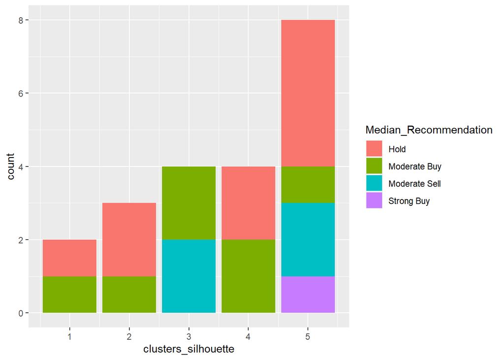

```r
ggplot(data_set2,aes(x=clusters_silhouette,fill=Median_Recommendation)) + geom_bar()
```

#Location

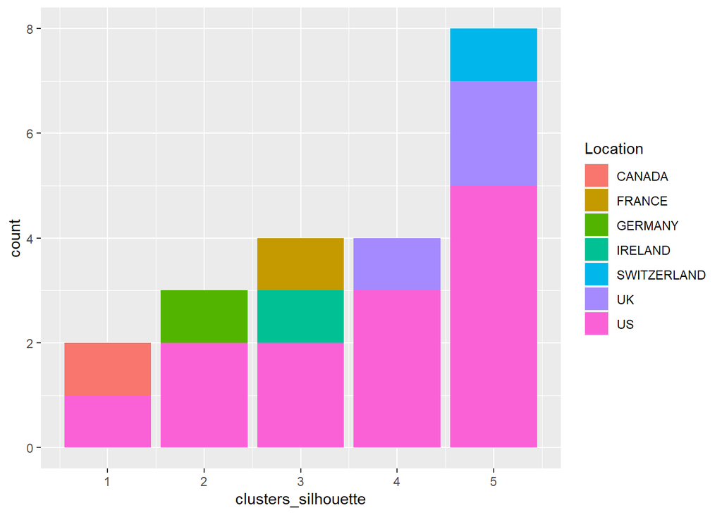

```r
ggplot(data_set2,aes(x=clusters_silhouette,fill=Location)) + geom_bar()
```

#Exchange

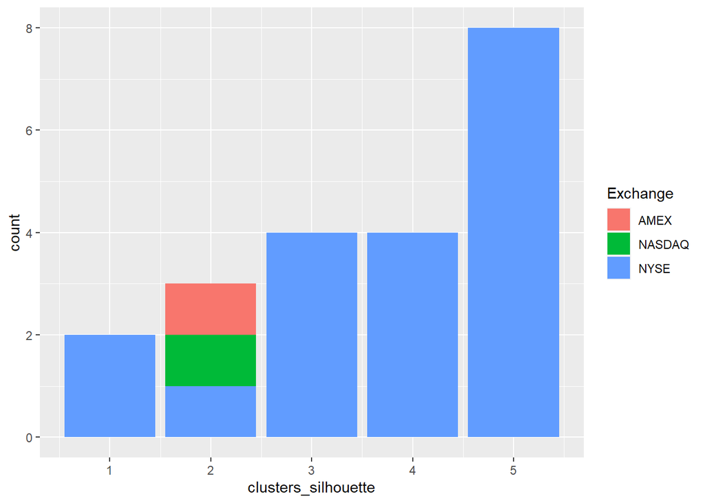

```r
ggplot(data_set2,aes(x=clusters_silhouette,fill=Exchange)) + geom_bar()
```